# Google Case Study: Wellness Technology Company

Idowu Efunogbon

August 11, 2022

## Bellabeat: How can a wellness technology company play it smart?

In this case study, I’ll demonstrate the steps to solve the Bellabeat Wellness company case study using Excel Spreadsheet, and R.

The following six phase of data analysis process is used for the case study: Ask, Prepare, Process, Analyze, Share, and Act.

#### **Table of Content:**

Summary

Characters and Products

Characters

Bellabeat Products

Ask Phase

Business Task

Prepare Phase

Data Availability

Process Phase

Analyze Phase and Share Phase

Act Phase (Conclusions and Recommendation)

#### **SUMMARY**

I am a Junior Data Analyst working on the Marketing Analyst Team at Bellabeat. Bellabeat which was founded in 2013, is a high-tech company that manufactures health-focused smart products for women around the world. These smart products collect women data on activity, sleep, stress and reproduction health and empower them with knowledge about their own health and habits.

#### **CHARACTERS AND PRODUCTS**

**CHARACTERS**

**Urška Sršen:** Bellabeat’s Cofounder and Chief Creative Officer

**Sando Mur:** Mathematician and Bellabeat’s cofounder; key member of the Bellabeat executive team

**Bellabeat marketing analytics team**

**BELLABEAT PRODUCTS**

**Bellabeat app**: The Bellabeat app provides users with health data related to their activity, sleep, stress, menstrual cycle, and mindfulness habits. This data can help users better understand their current habits and make healthy decisions. The Bellabeat app connects to their line of smart wellness products.

**Leaf:** Bellabeat’s classic wellness tracker can be worn as a bracelet, necklace, or clip. The Leaf tracker connects to the Bellabeat app to track activity, sleep, and stress.

**Time:** This wellness watch combines the timeless look of a classic timepiece with smart technology to track user activity, sleep, and stress. The Time watch connects to the Bellabeat app to provide you with insights into your daily wellness.

**Spring:** This is a water bottle that tracks daily water intake using smart technology to ensure that you are appropriately hydrated throughout the day. The Spring bottle connects to the Bellabeat app to track your hydration levels.

**Bellabeat membership:** Bellabeat offers a subscription-based membership program for users. Membership gives users 24/7 access to fully personalized guidance on nutrition, activity, sleep, health and beauty, and mindfulness based on their lifestyle and goals.

#### **ASK:**

Why conduct the analysis, what problem am I trying to solve, and defined the problem by understanding the stakeholders expectation.

**Why conduct the analysis:** What are some trends in smart device usage? How could these trends apply to Bellabeat customers? How could these trends help influence Bellabeat marketing strategy?

**Business Task:** Identify trends on how consumers use their non-bellabeat smart device, and make recommendation on how Bellabeat marketing team can leverage on my analysis to improve the bellabeat marketing strategy.

**Stakeholders:** Urška Sršen: Bellabeat’s Cofounder and Chief Creative Officer

Sando Mur: Mathematician and Bellabeat’s cofounder; key member of the Bellabeat executive team

Bellabeat marketing analytics team

#### **PREPARE:**

**Data:** The Data used for carrying out this analysis is the [Fitbit Fitness Tracker Data](https://www.kaggle.com/datasets/arashnic/fitbit) (CC0: Public Domain, dataset made available through [Mobius](https://www.kaggle.com/arashnic)).It is a public dataset and can be downloaded from Kaggle website.

**Data Organization:** The Fitbit Dataset; The folder named Fitabase Data 4.12.16-5.12.16 is a structured dataset that contains 18 CSV files. Each csv file have different quantitative data on women physical activity, heart rate, and sleep monitoring. The dataset ( in each CSV file) is in long format that is it contains values that do repeat in the first column. The value in the first column which is the user ID are repeated.

**Data licensing & privacy:** The data is an open-source data (license is CCO: public Domain) from Kaggle website that is the data is available to the public for use.

#### **PROCESS:**

I will be using R and SQL to carry out my analysis. visualization and report.

After exploring the 18 csv files, I streamline my analysis to using 4 csv files. The following are the csv files for my case study:

*dailyActivity_merged*

*Steps_merged*

*sleepDay_merged*

*weightLogInfo_merged*

**Installing packages and opening libraries** The following packages are loaded in order to carry out my analysis:

```r
# opinionated collection of R packages designed for data science
library(tidyverse)
library(lubridate)
```

```r
 #for data visualization
library(ggplot2)

# a structure of data manipulation that help resolve the most frequent data
library("dplyr")
```

**Importing Datasets**

```r
#For this project I will be loading 4 csv files out of the 19 sheets for my analysis

daily_activity <- read.csv("C:/Desktop/Analytics Certificate/Course 8/dailyActivity_merged.csv")
daily_steps <- read.csv("C:/Desktop/Analytics Certificate/Course 8/dailySteps_merged.csv")
weight_log_info <- read.csv("C:/Desktop/Analytics Certificate/Course 8/weightLogInfo_merged.csv")
daily_sleep <- read.csv("C:/Desktop/Analytics Certificate/Course 8/sleepDay_merged.csv")


# To display the structure of each columns in daily activity

str(daily_activity)
```

```
## 'data.frame':    940 obs. of  15 variables:
##  $ Id                      : num  1.5e+09 1.5e+09 1.5e+09 1.5e+09 1.5e+09 ...
##  $ ActivityDate            : chr  "4/12/2016" "4/13/2016" "4/14/2016" "4/15/2016" ...
##  $ TotalSteps              : int  13162 10735 10460 9762 12669 9705 13019 15506 10544 9819 ...
##  $ TotalDistance           : num  8.5 6.97 6.74 6.28 8.16 ...
##  $ TrackerDistance         : num  8.5 6.97 6.74 6.28 8.16 ...
##  $ LoggedActivitiesDistance: num  0 0 0 0 0 0 0 0 0 0 ...
##  $ VeryActiveDistance      : num  1.88 1.57 2.44 2.14 2.71 ...
##  $ ModeratelyActiveDistance: num  0.55 0.69 0.4 1.26 0.41 ...
##  $ LightActiveDistance     : num  6.06 4.71 3.91 2.83 5.04 ...
##  $ SedentaryActiveDistance : num  0 0 0 0 0 0 0 0 0 0 ...
##  $ VeryActiveMinutes       : int  25 21 30 29 36 38 42 50 28 19 ...
##  $ FairlyActiveMinutes     : int  13 19 11 34 10 20 16 31 12 8 ...
##  $ LightlyActiveMinutes    : int  328 217 181 209 221 164 233 264 205 211 ...
##  $ SedentaryMinutes        : int  728 776 1218 726 773 539 1149 775 818 838 ...
##  $ Calories                : int  1985 1797 1776 1745 1863 1728 1921 2035 1786 1775 ...
```

```r
# To display the columns and first serveral rows in daily activity datset.
head(daily_activity)
```

```
##           Id ActivityDate TotalSteps TotalDistance TrackerDistance
## 1 1503960366    4/12/2016      13162          8.50            8.50
## 2 1503960366    4/13/2016      10735          6.97            6.97
## 3 1503960366    4/14/2016      10460          6.74            6.74
## 4 1503960366    4/15/2016       9762          6.28            6.28
## 5 1503960366    4/16/2016      12669          8.16            8.16
## 6 1503960366    4/17/2016       9705          6.48            6.48
##   LoggedActivitiesDistance VeryActiveDistance ModeratelyActiveDistance
## 1                        0               1.88                     0.55
## 2                        0               1.57                     0.69
## 3                        0               2.44                     0.40
## 4                        0               2.14                     1.26
## 5                        0               2.71                     0.41
## 6                        0               3.19                     0.78
##   LightActiveDistance SedentaryActiveDistance VeryActiveMinutes
## 1                6.06                       0                25
## 2                4.71                       0                21
## 3                3.91                       0                30
## 4                2.83                       0                29
## 5                5.04                       0                36
## 6                2.51                       0                38
##   FairlyActiveMinutes LightlyActiveMinutes SedentaryMinutes Calories
## 1                  13                  328              728     1985
## 2                  19                  217              776     1797
## 3                  11                  181             1218     1776
## 4                  34                  209              726     1745
## 5                  10                  221              773     1863
## 6                  20                  164              539     1728
```

```r
# To display the column name of daily_activity dataframe
colnames(daily_activity)
```

```
##  [1] "Id"                       "ActivityDate"
##  [3] "TotalSteps"               "TotalDistance"
##  [5] "TrackerDistance"          "LoggedActivitiesDistance"
##  [7] "VeryActiveDistance"       "ModeratelyActiveDistance"
##  [9] "LightActiveDistance"      "SedentaryActiveDistance"
## [11] "VeryActiveMinutes"        "FairlyActiveMinutes"
## [13] "LightlyActiveMinutes"     "SedentaryMinutes"
## [15] "Calories"
```

```r
# columns of the dataset and display some portion of the data with respect to each attribute
library(tidyverse)

glimpse(daily_activity)
```

```
## Rows: 940
## Columns: 15
## $ Id                       <dbl> 1503960366, 1503960366, 1503960366, 150396036…
## $ ActivityDate             <chr> "4/12/2016", "4/13/2016", "4/14/2016", "4/15/…
## $ TotalSteps               <int> 13162, 10735, 10460, 9762, 12669, 9705, 13019…
## $ TotalDistance            <dbl> 8.50, 6.97, 6.74, 6.28, 8.16, 6.48, 8.59, 9.8…
## $ TrackerDistance          <dbl> 8.50, 6.97, 6.74, 6.28, 8.16, 6.48, 8.59, 9.8…
## $ LoggedActivitiesDistance <dbl> 0, 0, 0, 0, 0, 0, 0, 0, 0, 0, 0, 0, 0, 0, 0, …
## $ VeryActiveDistance       <dbl> 1.88, 1.57, 2.44, 2.14, 2.71, 3.19, 3.25, 3.5…
## $ ModeratelyActiveDistance <dbl> 0.55, 0.69, 0.40, 1.26, 0.41, 0.78, 0.64, 1.3…
## $ LightActiveDistance      <dbl> 6.06, 4.71, 3.91, 2.83, 5.04, 2.51, 4.71, 5.0…
## $ SedentaryActiveDistance  <dbl> 0, 0, 0, 0, 0, 0, 0, 0, 0, 0, 0, 0, 0, 0, 0, …
## $ VeryActiveMinutes        <int> 25, 21, 30, 29, 36, 38, 42, 50, 28, 19, 66, 4…
## $ FairlyActiveMinutes      <int> 13, 19, 11, 34, 10, 20, 16, 31, 12, 8, 27, 21…
## $ LightlyActiveMinutes     <int> 328, 217, 181, 209, 221, 164, 233, 264, 205, …
## $ SedentaryMinutes         <int> 728, 776, 1218, 726, 773, 539, 1149, 775, 818…
## $ Calories                 <int> 1985, 1797, 1776, 1745, 1863, 1728, 1921, 203…
```

```r
# To display the summary of each columns in daily steps
str(daily_steps)
```

```
## 'data.frame':    940 obs. of  3 variables:
##  $ Id         : num  1.5e+09 1.5e+09 1.5e+09 1.5e+09 1.5e+09 ...
##  $ ActivityDay: chr  "4/12/2016" "4/13/2016" "4/14/2016" "4/15/2016" ...
##  $ StepTotal  : int  13162 10735 10460 9762 12669 9705 13019 15506 10544 9819 ...
```

```r
# To display the columns and first serveral rows in daily daily steps.
head(daily_steps)
```

```
##           Id ActivityDay StepTotal
## 1 1503960366   4/12/2016     13162
## 2 1503960366   4/13/2016     10735
## 3 1503960366   4/14/2016     10460
## 4 1503960366   4/15/2016      9762
## 5 1503960366   4/16/2016     12669
## 6 1503960366   4/17/2016      9705
```

```r
# To display the column name
colnames(daily_steps)
```

```
## [1] "Id"          "ActivityDay" "StepTotal"
```

```r
# columns of the dataset and display some portion of the data with respect to each attribute
glimpse(daily_steps)
```

```
## Rows: 940
## Columns: 3
## $ Id          <dbl> 1503960366, 1503960366, 1503960366, 1503960366, 1503960366…
## $ ActivityDay <chr> "4/12/2016", "4/13/2016", "4/14/2016", "4/15/2016", "4/16/…
## $ StepTotal   <int> 13162, 10735, 10460, 9762, 12669, 9705, 13019, 15506, 1054…
```

```r
# To display the structure of each columns in daily weight log info
str(weight_log_info)
```

```
## 'data.frame':    67 obs. of  8 variables:
##  $ Id            : num  1.50e+09 1.50e+09 1.93e+09 2.87e+09 2.87e+09 ...
##  $ Date          : chr  "5/2/2016 11:59:59 PM" "5/3/2016 11:59:59 PM" "4/13/2016 1:08:52 AM" "4/21/2016 11:59:59 PM" ...
##  $ WeightKg      : num  52.6 52.6 133.5 56.7 57.3 ...
##  $ WeightPounds  : num  116 116 294 125 126 ...
##  $ Fat           : int  22 NA NA NA NA 25 NA NA NA NA ...
##  $ BMI           : num  22.6 22.6 47.5 21.5 21.7 ...
##  $ IsManualReport: chr  "True" "True" "False" "True" ...
##  $ LogId         : num  1.46e+12 1.46e+12 1.46e+12 1.46e+12 1.46e+12 ...
```

```r
# To display the columns and first serveral rows in daily weight log info.
head(weight_log_info)
```

```
##           Id                  Date WeightKg WeightPounds Fat   BMI
## 1 1503960366  5/2/2016 11:59:59 PM     52.6     115.9631  22 22.65
## 2 1503960366  5/3/2016 11:59:59 PM     52.6     115.9631  NA 22.65
## 3 1927972279  4/13/2016 1:08:52 AM    133.5     294.3171  NA 47.54
## 4 2873212765 4/21/2016 11:59:59 PM     56.7     125.0021  NA 21.45
## 5 2873212765 5/12/2016 11:59:59 PM     57.3     126.3249  NA 21.69
## 6 4319703577 4/17/2016 11:59:59 PM     72.4     159.6147  25 27.45
##   IsManualReport        LogId
## 1           True 1.462234e+12
## 2           True 1.462320e+12
## 3          False 1.460510e+12
## 4           True 1.461283e+12
## 5           True 1.463098e+12
## 6           True 1.460938e+12
```

```r
# To display the column name
colnames(weight_log_info)
```

```
## [1] "Id"             "Date"           "WeightKg"       "WeightPounds"
## [5] "Fat"            "BMI"            "IsManualReport" "LogId"
```

```r
# columns of the dataset and display some portion of the data with respect to each attribute
glimpse(weight_log_info)
```

```
## Rows: 67
## Columns: 8
## $ Id             <dbl> 1503960366, 1503960366, 1927972279, 2873212765, 2873212…
## $ Date           <chr> "5/2/2016 11:59:59 PM", "5/3/2016 11:59:59 PM", "4/13/2…
## $ WeightKg       <dbl> 52.6, 52.6, 133.5, 56.7, 57.3, 72.4, 72.3, 69.7, 70.3, …
## $ WeightPounds   <dbl> 115.9631, 115.9631, 294.3171, 125.0021, 126.3249, 159.6…
## $ Fat            <int> 22, NA, NA, NA, NA, 25, NA, NA, NA, NA, NA, NA, NA, NA,…
## $ BMI            <dbl> 22.65, 22.65, 47.54, 21.45, 21.69, 27.45, 27.38, 27.25,…
## $ IsManualReport <chr> "True", "True", "False", "True", "True", "True", "True"…
## $ LogId          <dbl> 1.462234e+12, 1.462320e+12, 1.460510e+12, 1.461283e+12,…
```

```r
# To display the structure of each columns in daily sleep
str(daily_sleep)
```

```
## 'data.frame':    413 obs. of  5 variables:
##  $ Id                : num  1.5e+09 1.5e+09 1.5e+09 1.5e+09 1.5e+09 ...
##  $ SleepDay          : chr  "4/12/2016 12:00:00 AM" "4/13/2016 12:00:00 AM" "4/15/2016 12:00:00 AM" "4/16/2016 12:00:00 AM" ...
##  $ TotalSleepRecords : int  1 2 1 2 1 1 1 1 1 1 ...
##  $ TotalMinutesAsleep: int  327 384 412 340 700 304 360 325 361 430 ...
##  $ TotalTimeInBed    : int  346 407 442 367 712 320 377 364 384 449 ...
```

```r
# To display the columns and first serveral rows in daily daily sleep.
head(daily_sleep)
```

```
##           Id              SleepDay TotalSleepRecords TotalMinutesAsleep
## 1 1503960366 4/12/2016 12:00:00 AM                 1                327
## 2 1503960366 4/13/2016 12:00:00 AM                 2                384
## 3 1503960366 4/15/2016 12:00:00 AM                 1                412
## 4 1503960366 4/16/2016 12:00:00 AM                 2                340
## 5 1503960366 4/17/2016 12:00:00 AM                 1                700
## 6 1503960366 4/19/2016 12:00:00 AM                 1                304
##   TotalTimeInBed
## 1            346
## 2            407
## 3            442
## 4            367
## 5            712
## 6            320
```

```r
# To display the column name
colnames(daily_sleep)
```

```
## [1] "Id"                 "SleepDay"           "TotalSleepRecords"
## [4] "TotalMinutesAsleep" "TotalTimeInBed"
```

```r
# columns of the dataset and display some portion of the data with respect to each attribute
glimpse(daily_sleep)
```

```
## Rows: 413
## Columns: 5
## $ Id                 <dbl> 1503960366, 1503960366, 1503960366, 1503960366, 150…
## $ SleepDay           <chr> "4/12/2016 12:00:00 AM", "4/13/2016 12:00:00 AM", "…
## $ TotalSleepRecords  <int> 1, 2, 1, 2, 1, 1, 1, 1, 1, 1, 1, 1, 1, 1, 1, 1, 1, …
## $ TotalMinutesAsleep <int> 327, 384, 412, 340, 700, 304, 360, 325, 361, 430, 2…
## $ TotalTimeInBed     <int> 346, 407, 442, 367, 712, 320, 377, 364, 384, 449, 3…
```

```r
# Cleaning and Formatting

# To check for error and inconsistency in the 3 tables that will be used for thea analysis
length(unique(daily_activity$Id))   # for daily_activity
```

```
## [1] 33
```

```r
length(unique(daily_sleep$Id))     # for daily_sleep
```

```
## [1] 24
```

```r
length(unique(weight_log_info$Id))    # for weight_log_info
```

```
## [1] 8
```

```r
length(unique(daily_steps$Id))     # For daily Steps
```

```
## [1] 33
```

#### To check for duplicates in daily activity

```r
sum(duplicated(daily_activity))
```

```
## [1] 0
```

No duplicate value

#### To check for duplicates in daily steps

```r
sum(duplicated(daily_steps))
```

```
## [1] 0
```

No duplicate value

#### To check for duplicate in daily sleep

```r
sum(duplicated(daily_sleep))
```

```
## [1] 3
```

Found 3 duplicate values in daily_sleep table.

```r
new_daily_sleep <-daily_sleep[!(duplicated(daily_sleep) | duplicated(daily_sleep, fromLast = TRUE)), ]
sum(duplicated(new_daily_sleep))
```

```
## [1] 0
```

No duplicate value

The “duplicated” function is used to test to if a line appears at least for the second time starting at line one. Both boolean results are combined with | (logical ‘or’) into a new vector which indicates all lines appearing more than once. The result of this is negated using ! thereby creating a boolean vector indicating lines appearing only once.

#### To check for duplicate in weight log info

```r
sum(duplicated(weight_log_info))
```

```
## [1] 0
```

No duplicate value

#### To check for missing values in 4 csv files

```r
any(is.na(daily_activity)) # check for missing values in daily activity dataframe
```

```
## [1] FALSE
```

```r
any(is.na(new_daily_sleep)) # check for missing values in new daily sleep dataframe
```

```
## [1] FALSE
```

```r
any(is.na(daily_steps)) # check for missing values in daily steps dataframe
```

```
## [1] FALSE
```

```r
any(is.na(weight_log_info)) # check for missing values in weight log info dataframe
```

```
## [1] TRUE
```

#### To remove NA column in weight log info

```r
library("dplyr")

new_weight_log_info <- select(weight_log_info, -Fat) # The "-" tell the select function that the column fat should be drop from the dataframe
head(new_weight_log_info)
```

```
##           Id                  Date WeightKg WeightPounds   BMI IsManualReport
## 1 1503960366  5/2/2016 11:59:59 PM     52.6     115.9631 22.65           True
## 2 1503960366  5/3/2016 11:59:59 PM     52.6     115.9631 22.65           True
## 3 1927972279  4/13/2016 1:08:52 AM    133.5     294.3171 47.54          False
## 4 2873212765 4/21/2016 11:59:59 PM     56.7     125.0021 21.45           True
## 5 2873212765 5/12/2016 11:59:59 PM     57.3     126.3249 21.69           True
## 6 4319703577 4/17/2016 11:59:59 PM     72.4     159.6147 27.45           True
##          LogId
## 1 1.462234e+12
## 2 1.462320e+12
## 3 1.460510e+12
## 4 1.461283e+12
## 5 1.463098e+12
## 6 1.460938e+12
```

#### To check for missing values in weight log info dataframe

```r
any(is.na(new_weight_log_info))
```

```
## [1] FALSE
```

No more missing value that is “False”

I noticed the date column in the 4 dataframe are store in character form, so it need to be converted to datetime type.Also, the 4 datasets for this analysis have the same column named “Id”

#### To check the number of distinct Id in daily_activity, daily_sleep and weight _log_info data frames

```r
n_distinct(daily_activity$Id)
```

```
## [1] 33
```

```r
n_distinct(daily_sleep$Id)
```

```
## [1] 24
```

```r
n_distinct(new_weight_log_info$Id)
```

```
## [1] 8
```

```r
n_distinct(daily_steps$Id)
```

```
## [1] 33
```

daily_activity and daily_steps have the same number of observations

#### To check the number of observation in daily_activity, daily_sleep and weight _log_info data frames

```r
nrow(daily_activity)
```

```
## [1] 940
```

```r
nrow(daily_sleep)
```

```
## [1] 413
```

```r
nrow(new_weight_log_info)
```

```
## [1] 67
```

```r
nrow(daily_steps)
```

```
## [1] 940
```

There are 940 records in daily_activity data, 413 in daily_sleep, 67 in weight_log_info and 940 records in daily_steps

Since the date column in the 4 dataframe are store in character form, it need to be converted to a datetime type. To create month, date and weekday columns into activity_date, weight_log_info and daily_sleep columns

#### Convert the char ActivityDate column to Date format

```r
# daily activity
daily_activity$Date <- as.Date(daily_activity$ActivityDate,"%m/%d/%Y")
daily_activity$Date
```

[output not shown]

[output cut: 173 more lines]

##### To create the month column using the conversion date dataframe

```r
daily_activity$Month <- format(daily_activity$Date,"%B")
daily_activity$Month
```

[output not shown]

[output cut: 90 more lines]

#### To create the weekday column using the conversation date dataframe

```r
daily_activity$WeekDay <- format(daily_activity$Date,"%A")
daily_activity$WeekDay
```

[output not shown]

[output cut: 142 more lines]

#### Convert the char SleepDay column to Date format

```r
# new daily sleep
new_daily_sleep$Date <- as.Date(new_daily_sleep$SleepDay,"%m/%d/%Y")
new_daily_sleep$Date
```

[output not shown]

[output cut: 67 more lines]

#### To create the month column using the conversion date dataframe

```r
new_daily_sleep$Month <- format(new_daily_sleep$Date,"%B")
new_daily_sleep$Month
```

[output not shown]

[output cut: 31 more lines]

#### To create the weekday column using the conversation date dataframe

```r
new_daily_sleep$Weekday <- format(new_daily_sleep$Date,"%A")
new_daily_sleep$Weekday
```

[output not shown]

[output cut: 53 more lines]

#### Convert the char Date column to Date format

```r
# weight_log_info
new_weight_log_info$New_Date <- as.Date(weight_log_info$Date,"%m/%d/%Y")
new_weight_log_info$New_Date
```

```
##  [1] "2016-05-02" "2016-05-03" "2016-04-13" "2016-04-21" "2016-05-12"
##  [6] "2016-04-17" "2016-05-04" "2016-04-18" "2016-04-25" "2016-05-01"
## [11] "2016-05-02" "2016-05-09" "2016-04-17" "2016-04-12" "2016-04-13"
## [16] "2016-04-14" "2016-04-15" "2016-04-16" "2016-04-17" "2016-04-18"
## [21] "2016-04-19" "2016-04-20" "2016-04-21" "2016-04-22" "2016-04-23"
## [26] "2016-04-24" "2016-04-25" "2016-04-27" "2016-04-28" "2016-04-29"
## [31] "2016-04-30" "2016-05-01" "2016-05-02" "2016-05-03" "2016-05-04"
## [36] "2016-05-05" "2016-05-06" "2016-05-07" "2016-05-08" "2016-05-09"
## [41] "2016-05-10" "2016-05-11" "2016-05-12" "2016-04-12" "2016-04-13"
## [46] "2016-04-14" "2016-04-16" "2016-04-18" "2016-04-19" "2016-04-20"
## [51] "2016-04-21" "2016-04-23" "2016-04-24" "2016-04-25" "2016-04-26"
## [56] "2016-04-27" "2016-04-28" "2016-04-29" "2016-04-30" "2016-05-01"
## [61] "2016-05-03" "2016-05-04" "2016-05-06" "2016-05-08" "2016-05-09"
## [66] "2016-05-11" "2016-05-12"
```

#### To create the month column using the conversion date dataframe

```r
new_weight_log_info$Month<- format(new_weight_log_info$New_Date,"%B")
new_weight_log_info$Month
```

```
##  [1] "May"   "May"   "April" "April" "May"   "April" "May"   "April" "April"
## [10] "May"   "May"   "May"   "April" "April" "April" "April" "April" "April"
## [19] "April" "April" "April" "April" "April" "April" "April" "April" "April"
## [28] "April" "April" "April" "April" "May"   "May"   "May"   "May"   "May"
## [37] "May"   "May"   "May"   "May"   "May"   "May"   "May"   "April" "April"
## [46] "April" "April" "April" "April" "April" "April" "April" "April" "April"
## [55] "April" "April" "April" "April" "April" "May"   "May"   "May"   "May"
## [64] "May"   "May"   "May"   "May"
```

#### To create the weekday column using the conversation date dataframe

```r
new_weight_log_info$WeekDay <- format(new_weight_log_info$New_Date,"%A")
new_weight_log_info$WeekDay
```

```
##  [1] "Monday"    "Tuesday"   "Wednesday" "Thursday"  "Thursday"  "Sunday"
##  [7] "Wednesday" "Monday"    "Monday"    "Sunday"    "Monday"    "Monday"
## [13] "Sunday"    "Tuesday"   "Wednesday" "Thursday"  "Friday"    "Saturday"
## [19] "Sunday"    "Monday"    "Tuesday"   "Wednesday" "Thursday"  "Friday"
## [25] "Saturday"  "Sunday"    "Monday"    "Wednesday" "Thursday"  "Friday"
## [31] "Saturday"  "Sunday"    "Monday"    "Tuesday"   "Wednesday" "Thursday"
## [37] "Friday"    "Saturday"  "Sunday"    "Monday"    "Tuesday"   "Wednesday"
## [43] "Thursday"  "Tuesday"   "Wednesday" "Thursday"  "Saturday"  "Monday"
## [49] "Tuesday"   "Wednesday" "Thursday"  "Saturday"  "Sunday"    "Monday"
## [55] "Tuesday"   "Wednesday" "Thursday"  "Friday"    "Saturday"  "Sunday"
## [61] "Tuesday"   "Wednesday" "Friday"    "Sunday"    "Monday"    "Wednesday"
## [67] "Thursday"
```

#### 1. DAILY ACTIVITY

#### Summary of daily_activity

```r
summary(daily_activity)
```

```
##        Id            ActivityDate         TotalSteps    TotalDistance
##  Min.   :1.504e+09   Length:940         Min.   :    0   Min.   : 0.000
##  1st Qu.:2.320e+09   Class :character   1st Qu.: 3790   1st Qu.: 2.620
##  Median :4.445e+09   Mode  :character   Median : 7406   Median : 5.245
##  Mean   :4.855e+09                      Mean   : 7638   Mean   : 5.490
##  3rd Qu.:6.962e+09                      3rd Qu.:10727   3rd Qu.: 7.713
##  Max.   :8.878e+09                      Max.   :36019   Max.   :28.030
##  TrackerDistance  LoggedActivitiesDistance VeryActiveDistance
##  Min.   : 0.000   Min.   :0.0000           Min.   : 0.000
##  1st Qu.: 2.620   1st Qu.:0.0000           1st Qu.: 0.000
##  Median : 5.245   Median :0.0000           Median : 0.210
##  Mean   : 5.475   Mean   :0.1082           Mean   : 1.503
##  3rd Qu.: 7.710   3rd Qu.:0.0000           3rd Qu.: 2.053
##  Max.   :28.030   Max.   :4.9421           Max.   :21.920
##  ModeratelyActiveDistance LightActiveDistance SedentaryActiveDistance
##  Min.   :0.0000           Min.   : 0.000      Min.   :0.000000
##  1st Qu.:0.0000           1st Qu.: 1.945      1st Qu.:0.000000
##  Median :0.2400           Median : 3.365      Median :0.000000
##  Mean   :0.5675           Mean   : 3.341      Mean   :0.001606
##  3rd Qu.:0.8000           3rd Qu.: 4.782      3rd Qu.:0.000000
##  Max.   :6.4800           Max.   :10.710      Max.   :0.110000
##  VeryActiveMinutes FairlyActiveMinutes LightlyActiveMinutes SedentaryMinutes
##  Min.   :  0.00    Min.   :  0.00      Min.   :  0.0        Min.   :   0.0
##  1st Qu.:  0.00    1st Qu.:  0.00      1st Qu.:127.0        1st Qu.: 729.8
##  Median :  4.00    Median :  6.00      Median :199.0        Median :1057.5
##  Mean   : 21.16    Mean   : 13.56      Mean   :192.8        Mean   : 991.2
##  3rd Qu.: 32.00    3rd Qu.: 19.00      3rd Qu.:264.0        3rd Qu.:1229.5
##  Max.   :210.00    Max.   :143.00      Max.   :518.0        Max.   :1440.0
##     Calories         Date               Month             WeekDay
##  Min.   :   0   Min.   :2016-04-12   Length:940         Length:940
##  1st Qu.:1828   1st Qu.:2016-04-19   Class :character   Class :character
##  Median :2134   Median :2016-04-26   Mode  :character   Mode  :character
##  Mean   :2304   Mean   :2016-04-26
##  3rd Qu.:2793   3rd Qu.:2016-05-04
##  Max.   :4900   Max.   :2016-05-12
```

The average mean count of daily_activity daily is 7638 and a total distance of 5.490km Average mean of active minutes daily is 21.16; Average mean of Sedentary minuts daily is 991.2’ The average calories consumed daily is 2304 kCal The average totalsteps is 7638

Since their is no demographic variables to classify how many steps is considered to be active in order to determine the type of user we have. I will be using the the article titled “How many steps a day is considered active” by Medical Author: Pallavi Suyog Uttekar, MD and reviewed on 7/15/2021 by Shaziya Allarakha, MD (https://www.medicinenet.com/how_many_steps_a_day_is_considered_active/article.htm).to classify the users.

Sedentary: Less than 5,000 steps per day

Low active: about 5,000 to 7,499 steps daily

Somewhat active: about 7,500 to 9,999 steps daily

Active: More than 10,000 steps daily

Highly active: More than 12,500 steps daily

#### To create a new table called usertype, we first calculate the daily_steps_average per user

```r
daily_step_average <- daily_activity %>%
  group_by(Id) %>%
  summarise (mean_daily_steps = mean(TotalSteps))


head(daily_step_average)
```

```
## # A tibble: 6 × 2
##           Id mean_daily_steps
##        <dbl>            <dbl>
## 1 1503960366           12117.
## 2 1624580081            5744.
## 3 1644430081            7283.
## 4 1844505072            2580.
## 5 1927972279             916.
## 6 2022484408           11371.
```

#### create the new table called usertype and classify the user based on the daily step average

```r
User_Type  <-daily_step_average %>%
  mutate(User_Type = case_when(
    mean_daily_steps< 5000 ~"Sedentary",mean_daily_steps >= 5000 & mean_daily_steps < 7499 ~ "Low Active",
    mean_daily_steps >= 7500 & mean_daily_steps < 9999 ~ "Somewhat Active",  mean_daily_steps >= 10000 ~ "Active",
    mean_daily_steps > 12500 ~ "Highly Active"))

head(User_Type)
```

```
## # A tibble: 6 × 3
##           Id mean_daily_steps User_Type
##        <dbl>            <dbl> <chr>
## 1 1503960366           12117. Active
## 2 1624580081            5744. Low Active
## 3 1644430081            7283. Low Active
## 4 1844505072            2580. Sedentary
## 5 1927972279             916. Sedentary
## 6 2022484408           11371. Active
```

#### create the percentage of each user type

```r
User_Type_percent<- User_Type %>%
  group_by(User_Type) %>%
  summarise(Total= n()) %>%
  mutate(labels =scales::percent(Total / sum(Total))) %>%
  arrange(desc(labels))

head(User_Type_percent)
```

```
## # A tibble: 4 × 3
##   User_Type       Total labels
##   <chr>           <int> <chr>
## 1 Low Active          9 27.3%
## 2 Somewhat Active     9 27.3%
## 3 Sedentary           8 24.2%
## 4 Active              7 21.2%
```

#### Plot the graph of each user type

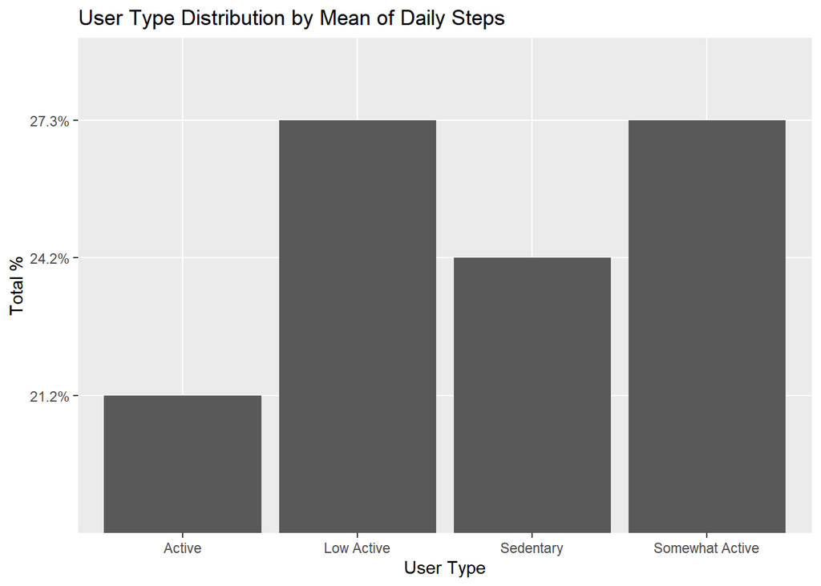

```r
ggplot (data= User_Type_percent, aes(x=User_Type, y=labels))+
  geom_col()+labs(x="User Type",y="Total %",title="User Type Distribution by Mean of Daily Steps")
```

From the graph, Low Active (27.3%) and Somewhat Active(27.3%) are relatively distributed among the user.

#### 2. WEIGHT LOG INFO

```r
#Summary of weight_log_info
summary(new_weight_log_info)
```

```
##        Id                Date              WeightKg       WeightPounds
##  Min.   :1.504e+09   Length:67          Min.   : 52.60   Min.   :116.0
##  1st Qu.:6.962e+09   Class :character   1st Qu.: 61.40   1st Qu.:135.4
##  Median :6.962e+09   Mode  :character   Median : 62.50   Median :137.8
##  Mean   :7.009e+09                      Mean   : 72.04   Mean   :158.8
##  3rd Qu.:8.878e+09                      3rd Qu.: 85.05   3rd Qu.:187.5
##  Max.   :8.878e+09                      Max.   :133.50   Max.   :294.3
##       BMI        IsManualReport         LogId              New_Date
##  Min.   :21.45   Length:67          Min.   :1.460e+12   Min.   :2016-04-12
##  1st Qu.:23.96   Class :character   1st Qu.:1.461e+12   1st Qu.:2016-04-19
##  Median :24.39   Mode  :character   Median :1.462e+12   Median :2016-04-27
##  Mean   :25.19                      Mean   :1.462e+12   Mean   :2016-04-26
##  3rd Qu.:25.56                      3rd Qu.:1.462e+12   3rd Qu.:2016-05-04
##  Max.   :47.54                      Max.   :1.463e+12   Max.   :2016-05-12
##     Month             WeekDay
##  Length:67          Length:67
##  Class :character   Class :character
##  Mode  :character   Mode  :character
##
##
##
```

The average weightkg is 72.04kg Average BMI is 25.19

#### 3. DAILY SLEEP

```r
#Summary of daily_sleep
summary(new_daily_sleep)
```

```
##        Id              SleepDay         TotalSleepRecords TotalMinutesAsleep
##  Min.   :1.504e+09   Length:407         Min.   :1.00      Min.   : 58.0
##  1st Qu.:3.977e+09   Class :character   1st Qu.:1.00      1st Qu.:361.0
##  Median :4.703e+09   Mode  :character   Median :1.00      Median :432.0
##  Mean   :4.989e+09                      Mean   :1.12      Mean   :418.9
##  3rd Qu.:6.962e+09                      3rd Qu.:1.00      3rd Qu.:490.0
##  Max.   :8.792e+09                      Max.   :3.00      Max.   :796.0
##  TotalTimeInBed       Date               Month             Weekday
##  Min.   : 61.0   Min.   :2016-04-12   Length:407         Length:407
##  1st Qu.:404.5   1st Qu.:2016-04-19   Class :character   Class :character
##  Median :463.0   Median :2016-04-27   Mode  :character   Mode  :character
##  Mean   :458.3   Mean   :2016-04-26
##  3rd Qu.:526.0   3rd Qu.:2016-05-04
##  Max.   :961.0   Max.   :2016-05-12
```

The mean total minutes asleep is 418.9 The average total time in bed is 458.3 minutes

##### 4. DAILY STEPS

```r
#Summary of daily_steps
summary(daily_steps)
```

```
##        Id            ActivityDay          StepTotal
##  Min.   :1.504e+09   Length:940         Min.   :    0
##  1st Qu.:2.320e+09   Class :character   1st Qu.: 3790
##  Median :4.445e+09   Mode  :character   Median : 7406
##  Mean   :4.855e+09                      Mean   : 7638
##  3rd Qu.:6.962e+09                      3rd Qu.:10727
##  Max.   :8.878e+09                      Max.   :36019
```

The average steptotal is 7638 steps

#### To calculate the most active days of the week

#### using the totalsteps by weekday

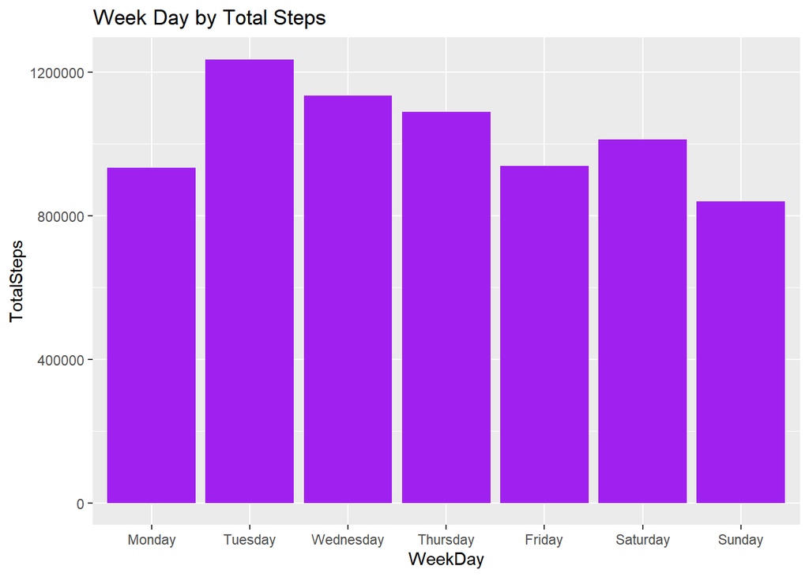

```r
# 1. Order the day of the week
daily_activity$WeekDay <- ordered(daily_activity$WeekDay,levels=c("Monday","Tuesday","Wednesday","Thursday","Friday","Saturday","Sunday"))

ggplot(data = daily_activity, aes(x= WeekDay, y = TotalSteps))+
  geom_col(fill="purple") + labs(x="WeekDay",y="TotalSteps",title = "Week Day by Total Steps")
```

User use FitBit fitness tracker application to track thier totalsteps mostly Tuesday, Wednesday, Thursday.This behaviour can be term as a result of users using the tracker to tack to track thierq daily activities.

#### using the VeryActiveMinutes by weekday

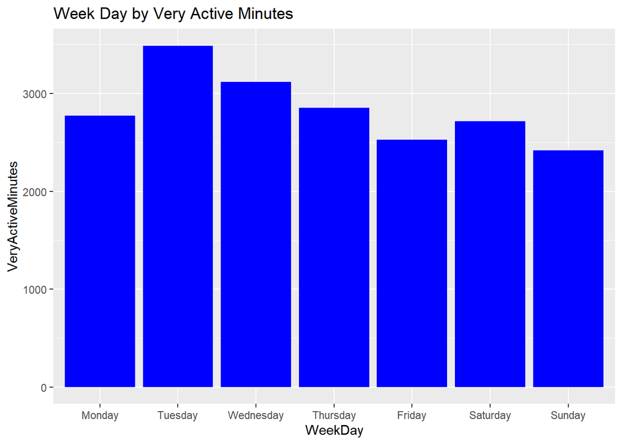

```r
#2.  Order the day of the week
daily_activity$WeekDay <- ordered(daily_activity$WeekDay,levels=c("Monday","Tuesday","Wednesday","Thursday","Friday","Saturday","Sunday"))


ggplot(data = daily_activity, aes(x= WeekDay, y = VeryActiveMinutes))+
  geom_col(fill="blue") + labs(x="WeekDay",y="VeryActiveMinutes",title = "Week Day by Very Active Minutes")
```

#### using the Calories by weekday

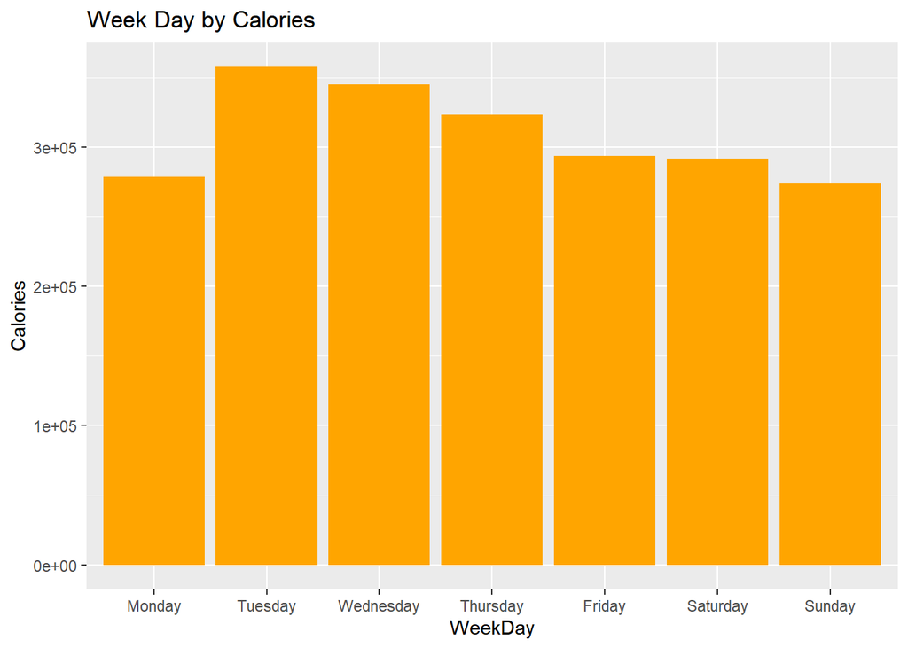

```r
# 3. Order the day of the week
daily_activity$WeekDay <- ordered(daily_activity$WeekDay,levels=c("Monday","Tuesday","Wednesday","Thursday","Friday","Saturday","Sunday"))


ggplot(data = daily_activity)+ geom_col(aes(x= WeekDay, y = Calories),fill= "orange")+
  labs(x="WeekDay",y="Calories",title = "Week Day by Calories")
```

User use FitBit fitness tracker application to track thier calories and Tuesday, Wednesday , Thursday have the hightest caloires burned.

#### 1. for Daily activity (Relation between Total Steps and SedentaryMinutes)

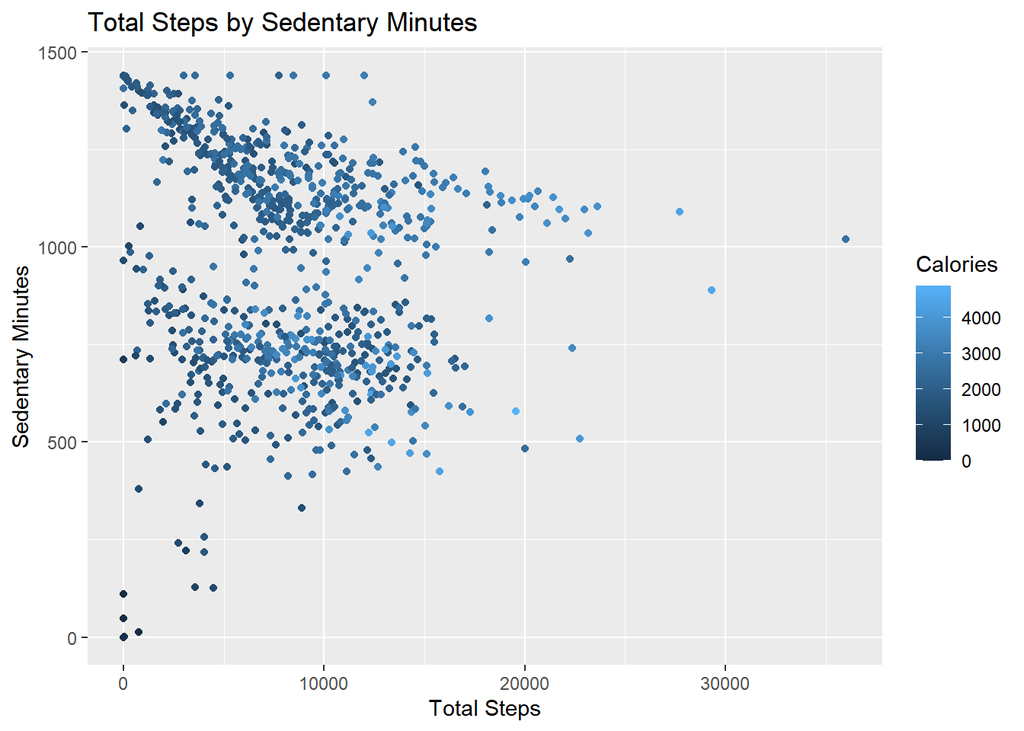

```r
ggplot (data= daily_activity, aes(x=TotalSteps, y=SedentaryMinutes,color= Calories))+
  geom_point()+ labs(x="Total Steps",y="Sedentary Minutes",title="Total Steps by Sedentary Minutes")
```

From the scatter graph, there is a negative relationship between total steps and sedentary miutes because people do not move when they are not physically active

#### 2. for Daily activity (To find if there is a relation between Total Steps by calories and colour of the line can be controlled using colour aesthetic

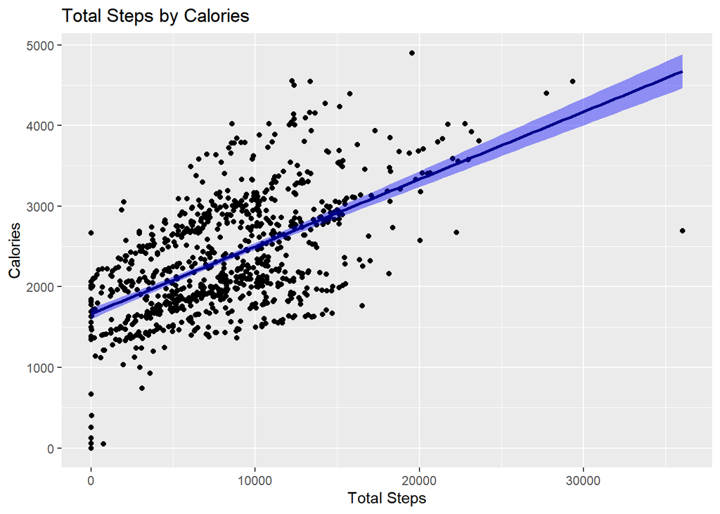

```r
ggplot(data=daily_activity, aes(x=TotalSteps, y = Calories))+ geom_point() + stat_smooth(method=lm, fill="blue", colour="darkblue", size=1)+
  labs(x="Total Steps",y="Calories",title="Total Steps by Calories")
```

From the plotted scatter graph, there is a positivecorrelation between the totalsteps and calories people that took the most total steps burn the most calories i.e the higher the steps the more calories user burn.

#### 3. To find if there is a relation between sleep and time in bed?

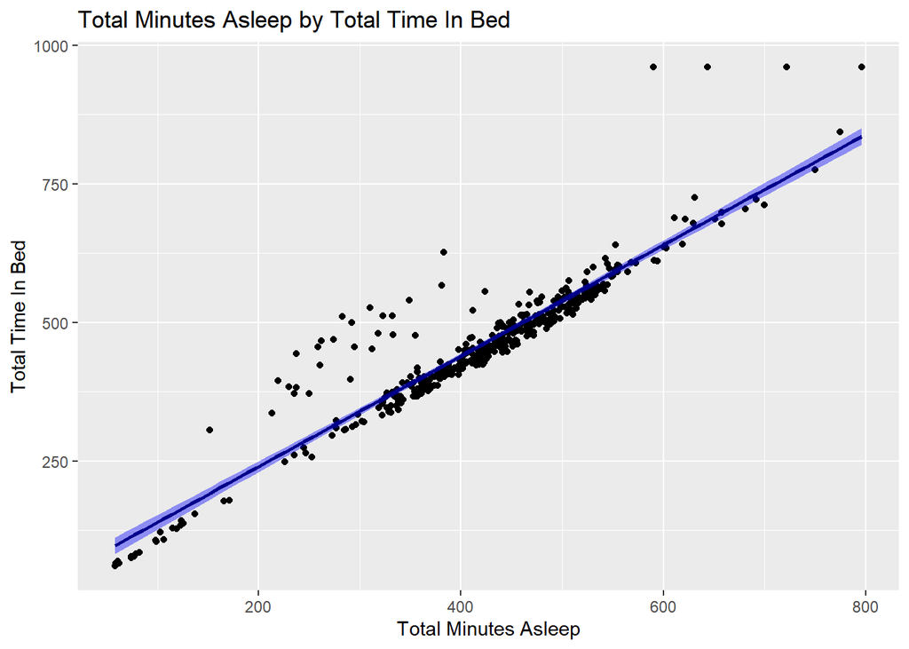

```r
ggplot(data= new_daily_sleep, aes(x=TotalMinutesAsleep, y=TotalTimeInBed)) + geom_point() + stat_smooth(method = lm,  fill="blue", colour="darkblue", size=1)+
  labs(x="Total Minutes Asleep",y="Total Time In Bed",title="Total Minutes Asleep by Total Time In Bed")
```

From the scatter graph, we noticed a strong positive correlation between TotalMinutesAsleep and TotalTimeInBed also we observed some outliers in the middle and top of the scatter plot. we can say the outliers are the people who spend lot of time in bed but did not actually sleep due to different reasons. To improve the sleep hours, a beep on the bellet time watch should be use to prepare user to sleep.

#### 4. To find if there is Relationship between active minutes and calories

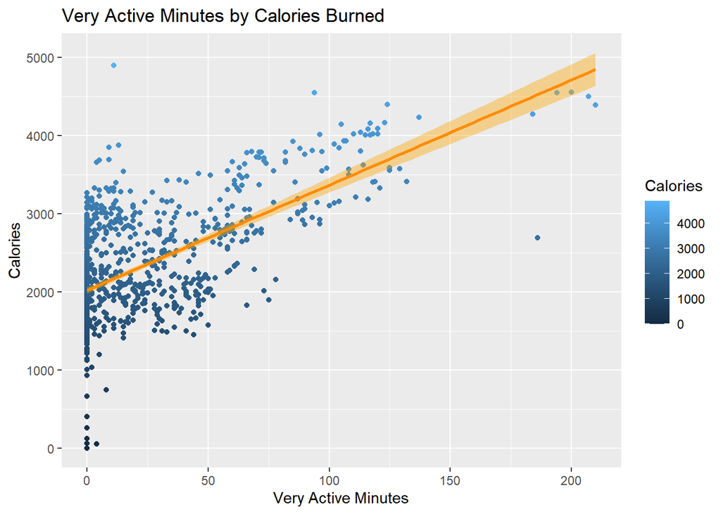

```r
ggplot(data=daily_activity,aes(x = VeryActiveMinutes, y = Calories, color = Calories)) + geom_point() + stat_smooth(method = lm,  fill="orange", colour="darkorange", size=1)+
labs(x="Very Active Minutes",y="Calories",title = "Very Active Minutes by Calories Burned")
```

From the graph, there is a strong correlation between very active minutes and calories burned with some outliers at bottom left and top left of the plot.

#### To plot daily sleep per week day

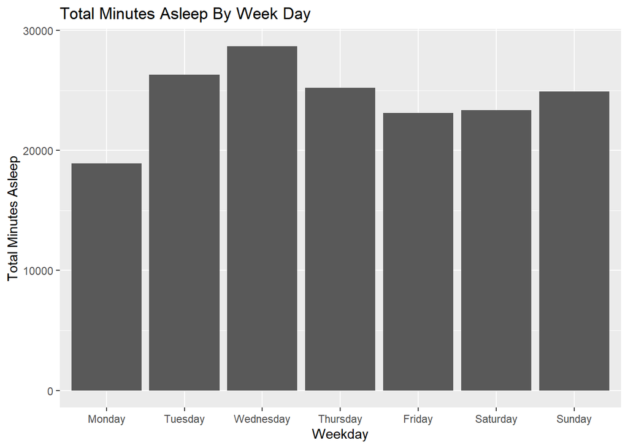

```r
# Order the day of the week
new_daily_sleep$Weekday <- ordered(new_daily_sleep$Weekday,levels=c("Monday","Tuesday","Wednesday","Thursday","Friday","Saturday","Sunday"))


ggplot(data = new_daily_sleep, aes(x= Weekday, y = TotalMinutesAsleep))+
  geom_col() + labs(x="Weekday",y="Total Minutes Asleep",title = "Total Minutes Asleep By Week Day")
```

User sleep most on Wednesday, and Tuesday while the least sleep day is on Monday.

#### To analyze the relationship of weight data, merge dailyactivity and new weight log info dataframes

```r
weight_daily_activity <- merge(daily_activity,new_weight_log_info, by = "Id")
head(weight_daily_activity)
```

```
##           Id ActivityDate TotalSteps TotalDistance TrackerDistance
## 1 1503960366    4/16/2016      12669          8.16            8.16
## 2 1503960366    4/16/2016      12669          8.16            8.16
## 3 1503960366    4/18/2016      13019          8.59            8.59
## 4 1503960366    4/18/2016      13019          8.59            8.59
## 5 1503960366    4/15/2016       9762          6.28            6.28
## 6 1503960366    4/15/2016       9762          6.28            6.28
##   LoggedActivitiesDistance VeryActiveDistance ModeratelyActiveDistance
## 1                        0               2.71                     0.41
## 2                        0               2.71                     0.41
## 3                        0               3.25                     0.64
## 4                        0               3.25                     0.64
## 5                        0               2.14                     1.26
## 6                        0               2.14                     1.26
##   LightActiveDistance SedentaryActiveDistance VeryActiveMinutes
```

[output cut: 27 more lines]

```r
summary(weight_daily_activity)
```

```
##        Id            ActivityDate         TotalSteps    TotalDistance
##  Min.   :1.504e+09   Length:2076        Min.   :    0   Min.   : 0.000
##  1st Qu.:6.962e+09   Class :character   1st Qu.: 7948   1st Qu.: 5.367
##  Median :6.962e+09   Mode  :character   Median :10762   Median : 7.410
##  Mean   :7.010e+09                      Mean   :11648   Mean   : 8.696
##  3rd Qu.:8.878e+09                      3rd Qu.:13928   3rd Qu.: 9.550
##  Max.   :8.878e+09                      Max.   :29326   Max.   :26.720
##
##  TrackerDistance  LoggedActivitiesDistance VeryActiveDistance
##  Min.   : 0.000   Min.   :0.000            Min.   : 0.0000
##  1st Qu.: 5.367   1st Qu.:0.000            1st Qu.: 0.1375
##  Median : 7.410   Median :0.000            Median : 1.7400
##  Mean   : 8.666   Mean   :0.145            Mean   : 3.3042
##  3rd Qu.: 9.080   3rd Qu.:0.000            3rd Qu.: 3.9000
##  Max.   :26.720   Max.   :4.082            Max.   :21.6600
##
##  ModeratelyActiveDistance LightActiveDistance SedentaryActiveDistance
##  Min.   :0.000            Min.   : 0.000      Min.   :0.000000
##  1st Qu.:0.080            1st Qu.: 3.610      1st Qu.:0.000000
##  Median :0.410            Median : 4.660      Median :0.000000
##  Mean   :0.659            Mean   : 4.701      Mean   :0.005039
##  3rd Qu.:1.070            3rd Qu.: 5.890      3rd Qu.:0.000000
##  Max.   :2.390            Max.   :10.710      Max.   :0.110000
##
##  VeryActiveMinutes FairlyActiveMinutes LightlyActiveMinutes SedentaryMinutes
##  Min.   :  0.00    Min.   : 0.00       Min.   :  0.0        Min.   :   0.0
##  1st Qu.:  7.00    1st Qu.: 4.00       1st Qu.:210.8        1st Qu.: 680.0
##  Median : 29.00    Median :12.00       Median :235.5        Median : 837.0
##  Mean   : 37.63    Mean   :14.45       Mean   :240.8        Mean   : 887.8
##  3rd Qu.: 61.00    3rd Qu.:22.00       3rd Qu.:288.0        3rd Qu.:1122.2
##  Max.   :210.00    Max.   :74.00       Max.   :448.0        Max.   :1440.0
##
##     Calories        Date.x             Month.x              WeekDay.x
##  Min.   :   0   Min.   :2016-04-12   Length:2076        Monday   :268
##  1st Qu.:1994   1st Qu.:2016-04-19   Class :character   Tuesday  :335
##  Median :2174   Median :2016-04-27   Mode  :character   Wednesday:335
##  Mean   :2519   Mean   :2016-04-26                      Thursday :334
##  3rd Qu.:3060   3rd Qu.:2016-05-05                      Friday   :268
##  Max.   :4552   Max.   :2016-05-12                      Saturday :268
##                                                         Sunday   :268
```

[output cut: 9 more lines]

```
##  Length:2076        Min.   :1.460e+12   Min.   :2016-04-12   Length:2076
##  Class :character   1st Qu.:1.461e+12   1st Qu.:2016-04-19   Class :character
##  Mode  :character   Median :1.462e+12   Median :2016-04-27   Mode  :character
##                     Mean   :1.462e+12   Mean   :2016-04-26
##                     3rd Qu.:1.462e+12   3rd Qu.:2016-05-04
##                     Max.   :1.463e+12   Max.   :2016-05-12
##
##   WeekDay.y
##  Length:2076
##  Class :character
##  Mode  :character
##
##
##
##
```

#### To plot the relationship between veryactiveminutes and weightin kg

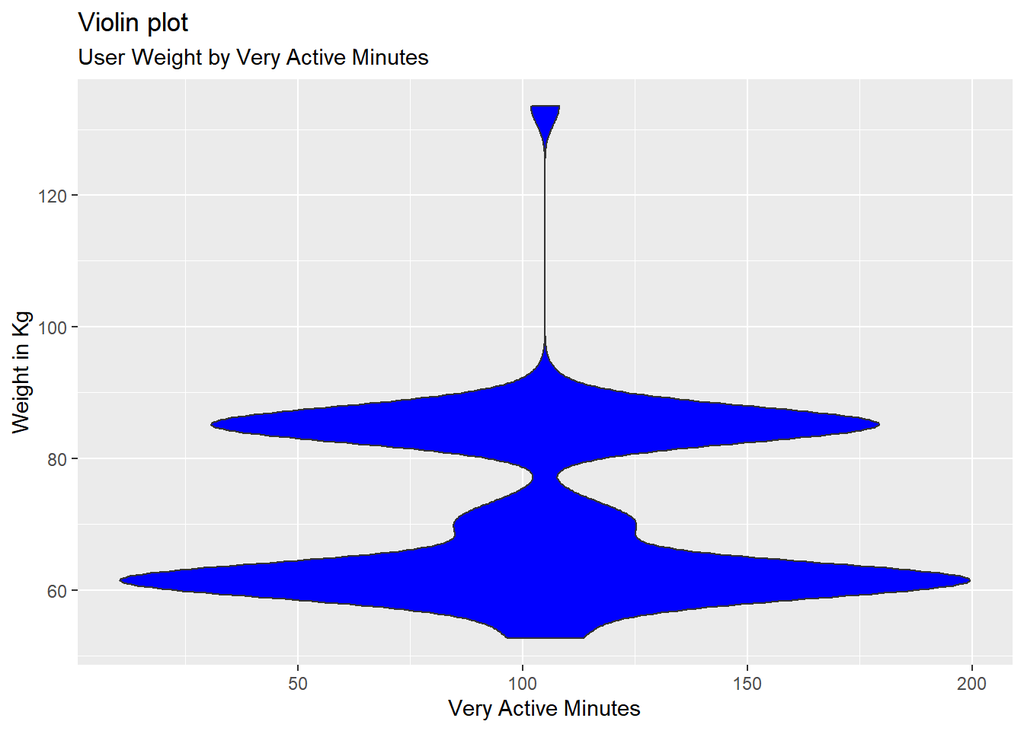

```r
ggplot(data=weight_daily_activity) + geom_violin(mapping=aes(x=VeryActiveMinutes, y=WeightKg), fill = "blue") +
labs(title="Violin plot", subtitle="User Weight by Very Active Minutes", x="Very Active Minutes", y="Weight in Kg")
```

From the violin plot, the median weight is 63.

Most users have a weight that is between 61 and 85, but some users have weight that are low as 53 and as high as 134. From the plot we can see outlier weight to be 134.

#### **ACT PHASE (CONCLUSION AND RECOMMENDATION)**

From the analysis carried out and using the business questions:

- The average total steps per day is 7638 which is below the 10,000 recommended steps per day which is termed the gold standards for adults. Therefore, the app should track users who do not meet the 10,000 recommended steps per day and send a reminder to to encourage them
- People tend to be more active on on Tuesday, Wednesday and Thursday so they tend to use their app on week days maybe because they spend more time outside compare to weekends
- Most users weight in Kg is between 61 - 85. Since bellabeat focus is on young and adult women empowerment and the data lack information on women Gender and Age therefore, there is need for more data on young and adult female gender, and age in order to meet bellabeat mission.
- Bellabeat marketing team can encourage users by educating them the benefits of the fitness, recommend the types of exercises users can partake in, calories intake and burn rate information on bellabeat application.
- The Bellebeat application should always send reminder during weekends to encourage users to exercise regularly.
- The Bellabeat app should create a reward system such that users who meet their daily steps goals would earn points which can be converted to discount for bellabeat membership at the end of every year